# ape_agents

**About**

This notebook was prepared by Dr. Karthik Mohan for the LLM 2024 course at University of Washington, Seattle and is inspired by this writeup: https://arxiv.org/abs/2401.14423

Lecture delivered on February 8, 2024

Class webpage: https://bytesizeml.github.io/llm2024/

Topics covered in Lecture:

1. Rails
2. Automated Prompt Engineering (APE)
3. Agents

### Setup

```python
# 1. Install Libraries
!pip3 install openai
!pip3 install python-dotenv


# 2. Connect to Google Drive
from google.colab import drive
drive.mount('/content/drive/', force_remount=True)

import os
print(os.system('ls'))

os.chdir(os.curdir + "/drive/MyDrive/Colab_Notebooks_LLM_2023")

# 3. Open AI API Access Setup
import openai
import os

open_ai_key_file = "openai_api_key_llm_2023.txt" # Your OPEN AI Key in this file
with open(open_ai_key_file, "r") as f:
  for line in f:
    OPENAI_KEY = line
    break

from dotenv import load_dotenv, find_dotenv
_ = load_dotenv(find_dotenv())


# 4. Tools Setup

import os

with open("google_cse_id.txt", "r") as f_cse:
  for line in f_cse:
    google_cse_id = line.strip("\n")
    break

with open("google_api_key.txt", "r") as f_cse:
  for line in f_cse:
    google_api_key = line.strip("\n")
    break

os.environ["GOOGLE_CSE_ID"] = google_cse_id
os.environ["GOOGLE_API_KEY"] = google_api_key

!pip3 install langchain
from langchain.tools import Tool
from langchain.utilities import GoogleSearchAPIWrapper

search = GoogleSearchAPIWrapper()

tool = Tool(
    name = "Google Search",
    description = "Search Google for recent results.",
    func = search.run
)
```

### OPEN AI Setup

```python
from openai import OpenAI
client = OpenAI(api_key=OPENAI_KEY)
def get_completion_instruct(prompt, model="gpt-3.5-turbo-instruct"):
    response = client.completions.create(
        model=model,
        prompt=prompt
    )
    #return response.choices[0].text
    return response.choices[0].text

def get_completion(prompt, model="gpt-3.5-turbo"):
  message = {"role": "user", "content": prompt}
  response = client.chat.completions.create(
      model=model,
      messages=[message]
  )
  return response.choices[0].message.content
```

## 1. Advanced Prompt Engineering

### A. Rails

Rails refers to "guard-rails" for LLMs - Directing and guiding the LLM to stick to certain styles of responses. Different types of rails:

1. Topical Rails: Ensures that LLM sticks to topic (staying relevant)
2. Fact-Checking Rails: Aimed at minimizing the generation of false or misleading information
3. Jail-breaking Rails: Prevent LLM from generating responses that bypass its own operational constraints or guidelines

You can use Topical and Fact-checking rails in your mini-project 2

### B. Automatic Prompt Engineering (APE)

1. Prompt engineering can be a time-consuming process that changes from task to task.
2. Automatic Prompt Engineering (APE) alleviates the time spent engineering good prompts through automated suggestion of prompts that would help with a task.
3. APE involves leveraging the capability of LLMs itself in generating good prompts for a given task.
4. (Self-Referential) In APE, an LLM can be asked to score and evaluate the prompts it generates
5. Post evaluation, LLM picks a prompt from APE that has the highest score and uses it as "its prompt" to solve the task!

#### APE Example 1

```python
def get_prompt(task):
  """
  Automatically Generate a prompt given a task
  """
  APE_prompt = "Given a task that I want accomplished by an LLM as follows, can you generate an appropriate prompt that I can pass in to get a good response. The prompt should include an example as well:  " + task
  prompt = get_completion(APE_prompt)
  return prompt
```

```python
task = "Explain the steps as visually seen for fixing a flat tire"
# NO APE
print(get_completion(task))
```

```
1. Identify the flat tire: visually inspect all four tires by walking around the car.

2. Park the car on a safe and flat surface: find a location away from traffic or any other hazards to ensure your safety.

3. Engage the parking brake: this will prevent the car from rolling.

4. Place a wheel chock: if available, place a wheel chock or a large rock behind one of the tires opposite to the one being changed for extra safety.

5. Retrieve essential tools: typically, you will need a spare tire, car jack, lug wrench, and a vehicle owner's manual. These tools are usually located in the trunk or under the car.

6. Position the car jack: consult the owner's manual to find the correct position for the jack. Typically, it goes under the car frame near the flat tire.

7. Use the lug wrench: attach the lug wrench to the lug nuts on the flat tire and turn counterclockwise to loosen them. Do not remove the lug nuts completely at this stage.

8. Lift the car: use the car jack to raise the car slowly and steadily until the flat tire is about six inches off the ground. Make sure the jack is positioned securely and aligned with the designated car lift point.

9. Remove the lug nuts: completely remove the loosened lug nuts and place them in a safe location, as they will be needed later.

10. Remove the flat tire: firmly hold both sides of the tire, and pull it straight towards you until it is free from the wheelbase.

11. Install the spare tire: align the spare tire with the exposed wheelbase by matching the holes in the rim with the wheel studs. Push the tire towards the car until it cannot go any further.

12. Hand-tighten the lug nuts: start by hand-threading the lug nuts onto the wheel studs to ensure proper alignment.

13. Lower the car: use the jack to lower the car slowly until it rests securely on the ground. Remove the car jack and place it back in the trunk.

14. Tighten the lug nuts: using the lug wrench, tighten the lug nuts as much as possible in a diagonal pattern. This ensures even pressure on the tire.

15. Double-check lug nut tightness: with the car on the ground, go over each lug nut again, tightening them further with the lug wrench.

16. Store the flat tire, tools, and spare tire: put the flat tire, tools, and lug wrench back in the trunk of the car. Ensure they are secure and won't shift during driving.

17. Check the spare tire pressure: visually inspect the spare tire to ensure it is adequately inflated. If necessary, take it to a gas station to fill it to the specified pressure level.

18. Get the flat tire repaired/replaced: visit an auto repair shop to fix the punctured tire or purchase a new one, depending on the severity of the damage.

19. Return the car jack and tools to their original location: put the car jack and all the tools used back in their designated spot, ensuring they are secured for future use.

20. Remember to remove the wheel chock: retrieve the wheel chock or large rock from behind the tire and place it back where it belongs.

Now, you are ready to continue your journey with a repaired or replaced tire.
```

```python
task = "Explain the steps as visually seen for fixing a flat tire"
prompt = get_prompt(task)

print("Automatically Generated Prompt: \n")
print(prompt)
print("\n\n LLM Response: \n")
print(get_completion(prompt))
```

```
Automatically Generated Prompt:

Prompt: Please provide a step-by-step explanation, with visual references, on how to fix a flat tire.

Example: Imagine you are driving down the road in your car when suddenly you hear a loud hissing noise. You quickly realize that you have a flat tire. In order to help others facing a similar issue, please provide a detailed explanation, accompanied by visual aids, on how to fix a flat tire.


 LLM Response:

Step 1: Find a Safe Location
The first step to fixing a flat tire is to find a safe location to pull over. This could be a nearby parking lot, a wide shoulder, or a flat, straight section of road. Ensure that you are away from traffic and have enough space to work comfortably.

Step 2: Gather Equipment
Before you start fixing the flat tire, gather all the necessary equipment. You will need:

- Spare tire
- Lug wrench
- Jack
- Wheel wedges
- Flashlight
- Vehicle owner's manual

Step 3: Apply Wheel Wedges
To prevent the vehicle from rolling, place wheel wedges, or blocks, on the opposite side of the flat tire. For example, if the front left tire is flat, place the wheel wedges behind the rear right tire.

Step 4: Loosen Lug Nuts
Next, locate the lug nuts on the flat tire. Using the lug wrench, turn the lug nuts counterclockwise to loosen them. You may need to apply force, as the lug nuts are typically tightened firmly. Be cautious not to completely remove them at this stage.

Step 5: Position Jack
Refer to your vehicle owner's manual to identify the proper lifting points for the jack. These points are usually marked on the frame of the vehicle. Once you've identified a suitable point, position the jack securely under the vehicle but do not lift the vehicle yet.

Step 6: Lift Vehicle
Using the appropriate jack, begin raising the vehicle until the flat tire is a few inches off the ground. Ensure that the jack is firmly placed and that the vehicle is stable before fully lifting it.

Step 7: Remove Lug Nuts and Flat Tire
With the vehicle raised, you can now remove the loosened lug nuts completely. Once removed, carefully take off the flat tire and set it aside.

Step 8: Mount Spare Tire
Position your spare tire onto the wheel base and align the holes in the rim with the lug bolts. Lift the tire and push it gently until it fits flush against the hub.

Step 9: Tighten Lug Nuts
Thread the lug nuts onto the lug bolts and tighten them by hand as much as possible. Use the lug wrench to further tighten the lug nuts, turning them clockwise. Tighten them in a star or cross pattern to ensure even tightening.

Step 10: Lower Vehicle
Using the jack, gradually lower the vehicle until all the weight is on the spare tire. Remove the jack and ensure the lug nuts are tightened securely.

Congratulations! You have successfully fixed your flat tire. Remember to have the damaged tire repaired or replaced as soon as possible, as spare tires are typically temporary solutions.

Note: The steps and equipment required may vary slightly depending on your vehicle. Always consult your vehicle owner's manual for specific instructions.
```

### ICE 1:

Use an APE function like above to automatically generate a prompt to execute the following task: "Generate streamlit code to develop a search bar that can take in a sentence and output relevant categories for the sentence as a response. The webapp should be simple, functional and have some style to it."

Also execute the LLM-generated prompt to check if the result looks reasonable.

```python
## ICE 1 - Your CODE HERE!
```

#### ICE 2 - LLM code to the rescue!

Copy the above LLM generated code over to an IDE on your laptop and execute it with streamlit to see if you get the desired web app with the specifications mentioned in the task above?

Post a screen shot of the web-app that got generated below!

```python
## ICE 2 - Your web-app Screenshot HERE!
```

### B2. APE with prompt scoring

```python
class APE:

  def __init__(self, model=None):
    self.model=model

  def prompt_generator(self, task):
    """
    Automatically Generate a prompt given a task
    """
    APE_prompt = "Given a task that I want accomplished by an LLM as follows, can you generate an appropriate prompt that I can pass in to get a good response. The prompt should include an example as well:  " + task
    if self.model:
      prompt = get_completion(APE_prompt,model=self.model)
    else:
      prompt = get_completion(APE_prompt)
    return prompt

  def prompt_evaluator(self,task):
    """
    Generate multiple automated prompts and evaluate them based on a criteria
    """

    prompts = [] # Initialize a list of prompts

    # Generate multiple prompts automatically
    for index in range(3):
      prompts.append(self.prompt_generator(task))

    # Prompt for evaluation
    evaluator_prompt = "Given the following list of prompts: " + str(prompts) + \
                        " ,evaluate and return goodness scores betweeen 0 and 1 on a) clarity and b) likelihood of generating a good response from LLM for the following task. Also make a recommendation for a prompt to use:" + \
                        task

    return prompts, get_completion(evaluator_prompt)
```

```python
task = "Explain the steps as visually seen for fixing a flat tire"
APE_instance = APE()
prompts, prompt_evaluations = APE_instance.prompt_evaluator(task) # Evaluate multiple Automatically Generated Prompts
index = 1
for prompt in prompts:
  print("\n Prompt " + str(index) + "\n")
  print(prompt)
  index += 1
print(prompt_evaluations)
```

```
 Prompt 1

Prompt: Guide me through the visual steps involved in fixing a flat tire on a car, providing a clear example for each step.

Example: Imagine you are driving down the road and suddenly you hear a loud thumping noise from one of your car's tires. You pull over to the side of the road to find that one of your tires is completely flat. In a detailed response, visually explain the step-by-step process of fixing a flat tire, i…

 Prompt 2

Title: Visual Guide: Step-by-Step Process for Fixing a Flat Tire

Prompt:
Your task is to provide a visual explanation of the sequential steps involved in fixing a flat tire. Please break down the process into easy-to-follow steps and include a diagram to illustrate each stage. Use clear and concise language along with a coherent structure to ensure clarity within your re…

Example Scenario:
Imagine you are driving home from work when suddenly you hear a loud "pop" followed by a noticeable decrease in vehicle control. You realize you have a flat tire and need to address the issue promptly. Detail the actions required to fix a flat tire using a visual representation, highlighting each st…

Please ensure that your response covers the following points:

1. Safety first: Explain the importance of finding a safe location away from traffic and activating hazard lights before attempting any repairs.
2. Prepare the vehicle: Outline the necessary steps to engage the parking brake, identify the appropriate tools (e.g., jack, lug wrench) from the spare tire kit, and locate the damaged tire.
3. Properly jack the vehicle: Describe the correct positioning of the jack to safely elevate the car, emphasizing the use of jack stand support for added stability.
4. Remove the damaged tire: Illustrate the process of loosening the lug nuts, explaining the preferred diagonal pattern and the importance of applying sufficient force.
5. Replace with spare tire: Explain the steps for aligning the spare tire with the designated wheel bolts, including tightening the lug nuts by hand initially.
6. Lower the vehicle and torque lug nuts: Demonstrate how to slowly lower the jack and then use the lug wrench to fully tighten the lug nuts.
7. Verify tire pressure: Advise checking the spare tire pressure to ensure it is within the safe range.
8. Secure the damaged tire: Suggest securing the flat tire in the trunk or designated storage area, as well as ensuring all tools are properly stored away.
9. Seek professional assistance: Emphasize the importance of visiting a tire professional to inspect the flat tire and determine whether it can be repaired or needs replacement.

Remember to provide a clear visual representation of each step, ensuring an easy-to-follow guide for the audience.

 Prompt 3

Please provide a step-by-step description of how to fix a flat tire, including visual cues to ensure clarity. Use the following example situation to explain your steps:

Example Situation: You are driving alone on a remote road, and suddenly you hear a loud pop followed by a bump. Your car begins to pull to the side, and you realize you have a flat tire. It's daytime, but there is no immediate help available.

Prompt: Using clear visuals and concise instructions, explain the step-by-step process of fixing a flat tire in the given example situation. Ensure the explanation covers the necessary tools, precautions, and any specific techniques required to successfully address the issue.
To evaluate the prompts and provide goodness scores for clarity and likelihood of generating a good response from LLM, let's analyze each prompt:

1. Prompt: Guide me through the visual steps involved in fixing a flat tire on a car, providing a clear example for each step.
   - Clarity: The prompt clearly asks for a visual explanation of the steps to fix a flat tire, including examples for each step.
   - Likelihood of generating a good response from LLM: Since the prompt explicitly asks for a visual guide with clear examples, it is likely to generate a good response from LLM.
   - Clarity score: 0.9
   - Likelihood score: 0.8

2. Title: Visual Guide: Step-by-Step Process for Fixing a Flat Tire
   - Clarity: The prompt asks for a visual explanation of the sequential steps involved in fixing a flat tire and provides a clear structure to follow.
   - Likelihood of generating a good response from LLM: It sets clear expectations for the response by specifying the necessary points to cover and requiring a visual representation.
   - Clarity score: 0.9
   - Likelihood score: 0.85

3. Please provide a step-by-step description of how to fix a flat tire, including visual cues to ensure clarity. Use the following example situation to explain your steps.
   - Clarity: The prompt asks for a step-by-step description with visual cues to ensure clarity and provides an example situation.
   - Likelihood of generating a good response from LLM: It provides a specific context for the response and emphasizes the inclusion of visual cues.
   - Clarity score: 0.85
   - Likelihood score: 0.9

Based on the evaluation, the recommended prompt to use is the second one:

Title: Visual Guide: Step-by-Step Process for Fixing a Flat Tire

This prompt provides a clear structure, emphasizes visual representation, and sets expectations by specifying the necessary points to cover.
```

### B3. APE using Automatic_Prompt_Engineer

As we saw in B2 - If the task is already clearly specified, then perhaps there is no need to do APE as the task description serves as a prompt.

Here, we look at a more useful use-case for APE using the APE library:

1. Assume there is a data set of (inputs, outputs)
2. For instance inputs and outputs could be drawn from a database table
3. You want to have APE figure out a prompt that captures the relationship between inputs and outputs and generate it.
4. Once the APE generates a good candidate prompt you can use it to for auto-generating outputs given an input
5. In this case, the APE is generating a prompt that can be used to automatically label inputs!

Very good use-case for LLM as an annotator!

We will now "attempt to" use a library for Automatic Prompt Engineering called Automatic Prompt Engineer: https://github.com/keirp/automatic_prompt_engineer

#### Attempt to use Automatic Prompt Engineer

```python
## Install Automatic Prompt Engineer
! pip install git+https://github.com/keirp/automatic_prompt_engineer
```

[output not shown]

```python
# First, let's define a simple dataset consisting of words and their antonyms.
words = ["sane", "direct", "informally", "unpopular", "subtractive", "nonresidential", \
    "inexact", "uptown", "incomparable", "powerful", "gaseous", "evenly", "formality",
    "deliberately", "off"]
antonyms = ["insane", "indirect", "formally", "popular", "additive", "residential",
    "exact", "downtown", "comparable", "powerless", "solid", "unevenly", "informality",
    "accidentally", "on"]
```

```python
eval_template = \
"""Instruction: [PROMPT]
Input: [INPUT]
Output: [OUTPUT]"""

# Now, let's use APE to find prompts that generate antonyms for each word.
from automatic_prompt_engineer import ape

result, demo_fn = ape.simple_ape(
    dataset=(words, antonyms),
    eval_template=eval_template,
)

# Let's see the results.
print(result)
```

[output not shown]

### B4. Using the class we created to generate a prompt automatically!

```python
task = "Given inputs: " + str(words) + " ,and their corresponding outputs: " + str(antonyms) + " ,a) you MUST find the relationship between inputs and outputs b) Using the relationship identified, write in a concise sentence a task that can generate an output given an input"
APE_instance = APE(model="gpt-4")
prompts, prompt_evaluations = APE_instance.prompt_evaluator(task) # Evaluate multiple Automatically Generated Prompts
index = 1
for prompt in prompts:
  print("\n Prompt " + str(index) + "\n")
  print(prompt)
  index += 1
print(prompt_evaluations)
```

```
 Prompt 1

Prompt:
The task involves the identification and understanding of the relationships between pairs of words. These pairs of words are opposites of each other. For example, the opposite of 'sane' is 'insane', and the opposite of 'direct' is 'indirect'. Given this pattern, your task is to find the opposite of …

 Prompt 2

Prompt:
Your task is to figure out the relationship between the two given list of words. Here is an example to help you understand the task:

Input: ['sane', 'direct', 'informally', 'unpopular', 'subtractive', 'nonresidential', 'inexact', 'uptown', 'incomparable', 'powerful', 'gaseous', 'evenly', 'formality', 'deliberately', 'off']
Output: ['insane', 'indirect', 'formally', 'popular', 'additive', 'residential', 'exact', 'downtown', 'comparable', 'powerless', 'solid', 'unevenly', 'informality', 'accidentally', 'on']

From this example, it seems that each output word is directly opposite in meaning to the corresponding input word. Using this pattern, the task is to convert a provided list of inputs into their opposite meanings. For instance, if the input is 'happy', the output should be 'unhappy'.

 Prompt 3

Prompt:
From the list of given pairs such as ['sane', 'insane'], ['direct', 'indirect'], ['informally', 'formally'], ['unpopular', 'popular'], ['subtractive', 'additive'], ['nonresidential', 'residential'], ['inexact', 'exact'], ['uptown', 'downtown'], ['incomparable', 'comparable'], ['powerful', 'powerless…

Example:
If the given input is 'unhappy', the task should correctly identify and return its antonym, which is 'happy'.
a) Clarity score: 0.8
The prompt clearly explains the task, which is to identify the opposite of each word in the given list. The example provided further clarifies the task by demonstrating how to find the opposite of a word. However, the prompt does not explicitly mention the term "opposite" but uses phrases like "anto…

b) Likelihood of generating a good response from LLM: 0.9
The task is well-defined and straightforward, making it likely to generate a good response from LLM. The example provides a clear understanding of the expected output and the pattern to follow.

Recommendation for a prompt to use:
"Prompt: Given a word as an input, your task is to find its antonym. For example, if the input is 'happy', your output should be 'unhappy'. Write a function or task that can generate the antonym of a given word."
```

#### Let's evaluate the prompt we just APE-generated!

```python
task = "Given inputs: " + str(words) + "For each word in the input, identify its antonym."
print(get_completion(task))
```

```
sane - insane
direct - indirect
informally - formally
unpopular - popular
subtractive - additive
nonresidential - residential
inexact - exact
uptown - downtown
incomparable - comparable
powerful - weak
gaseous - solid
evenly - unevenly
formality - informality
deliberately - accidentally
off - on
```

### B5. Another APE example

Working with numbers

```python
# Fibonacci series: 0 1 1 2 3 5 8 13 21 34
inputs = [1,2,5,21]
outputs = [1,3,8,34]
task = "Given inputs: " + str(inputs) + " ,and their corresponding outputs: " + str(outputs) + " ,a) You MUST find the relationship between inputs and outputs and respond in a single sentence. Also verify that this relationship is true. b) Using the relationship identified, write in a concise sentence a task that can generate an output for every input in the input list"
APE_instance = APE()
prompts, prompt_evaluations = APE_instance.prompt_evaluator(task) # Evaluate multiple Automatically Generated Prompts
index = 1
for prompt in prompts:
  print("\n Prompt " + str(index) + "\n")
  print(prompt)
  index += 1
print(prompt_evaluations)
```

```
 Prompt 1

a) The relationship between the inputs and outputs is that each output is generated by multiplying the corresponding input by itself and adding the input to the result. The relationship is true for all the given examples.

b) Write a task to generate an output for every input in the input list by multiplying each input by itself and adding the input to the result. For example, given an input of 5, the task would generate an output of 5 multiplied by 5 plus 5, resulting in 34.

 Prompt 2

Prompt: Please identify the relationship between the given inputs [1, 2, 5, 21] and their corresponding outputs [1, 3, 8, 34] in a single sentence and verify its accuracy. Then, formulate a concise task that can generate an output for every input in the input list using the identified relationship.

Example Task Prompt:
Consider the inputs [1, 2, 5, 21] and their corresponding outputs [1, 3, 8, 34]. The relationship between inputs and outputs is that each output can be obtained by multiplying the corresponding input by its index plus one. To generate an output for each input in the list, the task is to multiply eac…

 Prompt 3

Prompt: Please examine the given inputs [1, 2, 5, 21] and their corresponding outputs [1, 3, 8, 34]. In a single sentence, identify the relationship between the inputs and outputs, ensuring its correctness. Additionally, provide a concise sentence that represents a task capable of generating an outp…

Example prompt to be passed into the system:
"Please determine the relationship between the given inputs [1, 2, 5, 21] and their corresponding outputs [1, 3, 8, 34]. The relationship is a Fibonacci sequence where each output is the sum of the previous two outputs, and this relationship holds true. Additionally, create a task that calculates th…
To evaluate the goodness scores and make a recommendation, let's analyze each prompt option:

Prompt a)
Clarity: The prompt clearly asks for the relationship between the inputs and outputs in a single sentence. (Score: 1)
Likelihood of generating a good response: The prompt provides a clear instruction to find the relationship and verify its accuracy. It is likely to elicit a good response from LLM. (Score: 1)

Prompt b)
Clarity: The prompt asks to write a concise task using the identified relationship to generate an output for each input. (Score: 1)
Likelihood of generating a good response: The prompt provides the necessary information and instruction to generate a task. It is likely to generate a good response from LLM. (Score: 1)

Prompt c)
Clarity: The prompt asks to identify the relationship between inputs and outputs in a single sentence and verify its correctness. (Score: 1)
Likelihood of generating a good response: The prompt provides clear instructions and identifies the relationship as a Fibonacci sequence. It is likely to elicit a good response from LLM. (Score: 1)

Based on the evaluation, all the prompts have high clarity and likelihood of generating good responses from LLM.

Recommendation: Any of the three prompts can be used, but Prompt b) provides the most concise and direct instruction for generating a task.
```

#### Let's use gpt-4

```python
inputs = [1,2,5,21]
outputs = [1,3,8,34]
task = "Given inputs: " + str(inputs) + " ,and their corresponding outputs: " + str(outputs) + " ,a) You MUST find the relationship between inputs and outputs and respond in a single sentence. Also verify that this relationship is true. b) Using the relationship identified, write in a concise sentence a task that can generate an output for every input in the input list"
APE_instance = APE(model="gpt-4")
prompts, prompt_evaluations = APE_instance.prompt_evaluator(task) # Evaluate multiple Automatically Generated Prompts
index = 1
for prompt in prompts:
  print("\n Prompt " + str(index) + "\n")
  print(prompt)
  index += 1
print(prompt_evaluations)
```

```
 Prompt 1

"Given a sequence of inputs [1, 2, 5, 21] with corresponding outputs [1, 3, 8, 34], identify the relationship between the inputs and outputs and confirm its validity in a single sentence. Then, based on the established relationship, generate a directive in a concise sentence that can be used to calc…

 Prompt 2

"In the provided data, inputs are [1, 2, 5, 21] and their corresponding outputs are [1, 3, 8, 34]. Describe the relationship between these inputs and outputs in a single sentence, and verify this relationship. Based on your observation, then provide a sentence that describes a task to generate an ou…

 Prompt 3

For a given list of inputs [1, 2, 5, 21] and corresponding outputs [1, 3, 8, 34], determine the relationship between the inputs and outputs and articulate this connection in a single sentence, verifying its accuracy. Once you have defined this relationship, use it in a brief sentence to describe a m…

Example:

Inputs: [2, 3, 4]
Outputs: [4, 9, 16]

The relationship between the inputs and their corresponding outputs is that each output is the square of its corresponding input. This relationship is verified as true because 2*2 = 4, 3*3 = 9, and 4*4 = 16. Using this relationship, you could generate an output for each input by taking the square of…
Prompt: 'Given a sequence of inputs [1, 2, 5, 21] with corresponding outputs [1, 3, 8, 34], identify the relationship between the inputs and outputs and confirm its validity in a single sentence. Then, based on the established relationship, generate a directive in a concise sentence that can be used…

a) Clarity score: 0.9
b) Likelihood of generating a good response from LLM: 0.8

Recommendation:
Given the clarity and likelihood scores, this prompt seems well-structured and likely to generate a good response from LLM. The relationship between inputs and outputs is clearly stated, and the task provided is concise and direct. Therefore, the recommendation is to use this prompt.
```

## C. LLM Agents

1. An autonomous entity that perceives the environment, makes a judgment of state and takes a decision based on that.
2. There is a perception of context, of when a question is asked, what is the nature of the query, etc
3. Agent can invoke sub-agents to help with sub-tasks
4. Example: Agent thinks it needs to calculate something using a calculator. Agent calls the calculator to query the computation and get response. Agent then uses the computed response in its over-all response.
5. Agent combines LLM + Tools + State tracking for better decision making
6. Examples: Weather Agent - Can use weather API and weather news to get latest on weather

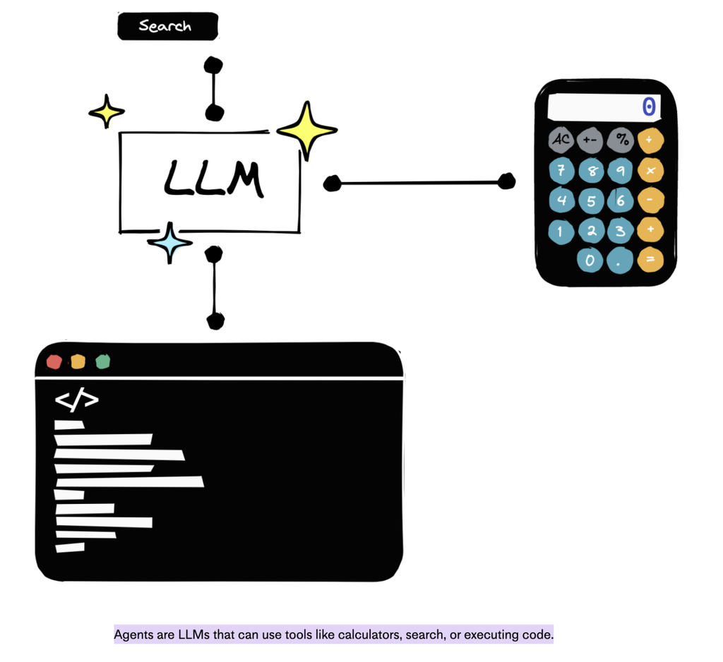

```python
from IPython.display import Image, display

imageName = "llm_agent_1.png" # Referenced from https://investor.fb.com/stock-info/
display(Image(filename=imageName))
```

### C1. Agent 101

```python
class LLMAgent:

  def __init__(self):
    pass


  def is_llm_topic(self, query):

    prompt = "Is this query about the technical aspects of an LLM? Answer in True or False: " + query
    return get_completion(prompt)

  def get_topic(self, query):
    prompt = "Return in one word, the topic of this query: " + query
    return get_completion(prompt)

  def main_agent(self, query):
    truth = str(self.is_llm_topic(query))
    if "True" in truth or "true" in truth:
      return self.llm_agent(query)
    else:
      topic = self.get_topic(query)
      return self.funny_agent(topic=topic)


  def funny_agent(self,topic="minion", style="hipster"):

    task = "Give me exactly one joke on " + topic + "." + " Crack the joke in " + style + " style."
    return get_completion(task)


  def llm_agent(self,query):
    task = "Assume you are a chatbot that responds to messages. You just got this message, respond to it appropriately: " + query
    return get_completion(task)
```

```python
llmagent = LLMAgent()
#print(llmagent.funny_agent())
query = "How do you avoid biases in llm annotations using open source LLMs?"
print("\n")
print(llmagent.main_agent(query))
print("\n")
query = "How's the weather in Seattle?"
print(llmagent.main_agent(query))
```

```
To avoid biases in LLM (Language Model) annotations while using open-source LLMs, several measures can be taken:

1. Diverse training data: Ensure that the training data used for the LLM includes a wide range of perspectives, sources, and demographics to minimize bias. This helps to prevent a skewed representation of a particular viewpoint.

2. Robust pre-training procedures: Implement rigorous pre-training procedures that explicitly address bias by closely scrutinizing the data sources and employing techniques like data cleaning, filtering, or augmentation.

3. Regular evaluations: Continuously evaluate the LLM's performance and annotation outputs to identify and rectify any potential biases that might arise. Regular assessments are crucial to maintaining fairness and minimizing skewed perspectives.

4. Multiple annotator reviews: Have multiple annotators review and validate the annotations produced by the LLM. This helps in identifying and addressing any potential biases or inaccuracies in the outputs.

5. Iterative refinement: Engage in an iterative process of fine-tuning the LLM by incorporating human feedback, including experts from diverse backgrounds, to ensure a broader and less biased perspective.

Remember, while these steps can help mitigate biases, it is challenging to completely eliminate biases from any language model.


Why did the cloud become a musician?

Because it was tired of its old job and decided to make some alt-rain!
```

```python
!ls
```

[output not shown]

```python
%shell jupyter nbconvert --to html ape_agents.ipynb
```